# Chapter 2: Descriptive Statistics

## 2.1 Stem-and-Leaf Graphs, Line Graphs, and Bar Graphs

One simple graph, the **stem-and-leaf graph** or **stemplot**, comes from the field of exploratory data analysis. It is a good choice when the data sets are small. To create the plot, divide each observation of data into a stem and a leaf. The leaf consists of a final **significant digit**. For example, 23 has stem two and leaf three. The number 432 has stem 43 and leaf two. Likewise, the number 5,432 has stem 543 and leaf two. The decimal 9.3 has stem nine and leaf three. Write the stems in a vertical line from smallest to largest. Draw a vertical line to the right of the stems. Then write the leaves in increasing order next to their corresponding stem.

#### Try It: Stem-and-Leaf Plot #1

For the Park City basketball team, scores for the last 30 games were as follows (smallest to largest):

32; 32; 33; 34; 38; 40; 42; 42; 43; 44; 46; 47; 47; 48; 48; 48; 49; 50; 50; 51; 52; 52; 52; 53; 54; 56; 57; 57; 60; and 61.

Construct a stem plot for the data.

```r
scores <- c(32, 32, 33, 34, 38, 40,
            42, 42, 43, 44, 46, 47,
            47, 48, 48, 48, 49, 50,
            50, 51, 52, 52, 52, 53,
            54, 56, 57, 57, 60, 61)

stem(scores)
```

```
##
##   The decimal point is 1 digit(s) to the right of the |
##
##   3 | 2234
##   3 | 8
##   4 | 02234
##   4 | 6778889
##   5 | 00122234
##   5 | 677
##   6 | 01
```

#### Try It: Stem-and-Leaf Plot #2

The data are the distances (in kilometers) from a home to local supermarkets. Create a stemplot using the data:

1.1; 1.5; 2.3; 2.5; 2.7; 3.2; 3.3; 3.3; 3.5; 3.8; 4.0; 4.2; 4.5; 4.5; 4.7; 4.8; 5.5; 5.6; 6.5; 6.7; 12.3

Do the data seem to have any concentration of values?

```r
scores <- c(1.1, 1.5, 2.3, 2.5, 2.7,
            3.2, 3.3, 3.3, 3.5, 3.8,
            4.0, 4.2, 4.5, 4.5, 4.7,
            4.8, 5.5, 5.6, 6.5, 6.7, 12.3)

stem(scores, scale = 2)
```

```
##
##   The decimal point is at the |
##
##    0 | 15
##    2 | 35723358
##    4 | 02557856
##    6 | 57
##    8 |
##   10 |
##   12 | 3
```

Based on the data in the stemplot, the value **12.3** may be an outlier. Values appear to concentrate at three and four kilometers.

#### Try It: Stem-and-Leaf Plot #3

The following data show the distances (in miles) from the homes of off-campus statistics students to the college. Create a stem plot using the data and identify any outliers:

0.5; 0.7; 1.1; 1.2; 1.2; 1.3; 1.3; 1.5; 1.5; 1.7; 1.7; 1.8; 1.9; 2.0; 2.2; 2.5; 2.6; 2.8; 2.8; 2.8; 3.5; 3.8; 4.4; 4.8; 4.9; 5.2; 5.5; 5.7; 5.8; 8.0

```r
scores <- c(0.5, 0.7, 1.1, 1.2, 1.2,
            1.3, 1.3, 1.5, 1.5, 1.7,
            1.7, 1.8, 1.9, 2.0, 2.2,
            2.5, 2.6, 2.8, 2.8, 2.8,
            3.5, 3.8, 4.4, 4.8, 4.9,
            5.2, 5.5, 5.7, 5.8, 8.0)

stem(scores, scale = 2)
```

```
##
##   The decimal point is at the |
##
##   0 | 57
##   1 | 12233
##   1 | 557789
##   2 | 02
##   2 | 56888
##   3 |
##   3 | 58
##   4 | 4
##   4 | 89
##   5 | 2
##   5 | 578
##   6 |
##   6 |
##   7 |
##   7 |
##   8 | 0
```

The value **8.0** may be an outlier. Values appear to concentrate at one and two miles.

#### Try It: Side-by-Side Stem-and-Leaf Plot

A **side-by-side stem-and-leaf plot** allows a comparison of the two data sets in two columns. In a side-by-side stem-and-leaf plot, two sets of leaves share the same stem. The leaves are to the left and the right of the stems. The two tables below show the ages of presidents at their inauguration and at their death. Construct a side-by-side stem-and-leaf plot using this data.

## Presidential Ages

```r
presidents <- c("Washington", "J. Adams", "Jefferson", "Madison",
                "Monroe", "J.Q. Adams", "Jackson", "Van Buren",
                "W. H. Harrison", "Tyler", "Polk", "Taylor", "Fillmore",
                "Pierce", "Buchanan", "Lincoln", "A. Johnson", "Grant",
                "Hayes", "Garfield", "Arthur", "Cleveland", "B. Harrison",
                "Cleveland", "McKinley", "T. Roosevelt", "Taft", "Wilson",
                "Harding", "Coolidge", "Hoover", "F. Roosevelt", "Truman",
                "Eisenhower", "Kennedy", "L. Johnson", "Nixon", "Ford",
                "Carter", "Reagan", "G.H.W. Bush", "Clinton",
                "G. W. Bush", "Obama")

inauguration_age <- c(57, 61, 57, 57, 58, 57, 61, 54,
                      68, 51, 49, 64, 50, 48, 65, 52,
                      56, 46, 54, 49, 51, 47, 55, 55,
                      54, 42, 51, 56, 55, 51, 54, 51,
                      60, 62, 43, 55, 56, 61, 52, 69,
                      64, 47, 54, 47)

death_age <- c(67, 90, 83, 85, 73, 80, 78, 79, 68,
               71, 53, 65, 74, 64, 77, 56, 66, 63,
               70, 49, 56, 71, 67, 71, 58, 60, 72,
               67, 57, 60, 90, 63, 88, 78, 46, 64,
               81, 93, NA, 93, NA, NA, NA, NA)

kable(as.data.frame(cbind("President" = presidents,
                          "Age" = inauguration_age)))
```

| President | Age |
| --- | --- |
| Washington | 57 |
| J. Adams | 61 |
| Jefferson | 57 |
| Madison | 57 |
| Monroe | 58 |
| J.Q. Adams | 57 |
| Jackson | 61 |
| Van Buren | 54 |
| W. H. Harrison | 68 |
| Tyler | 51 |
| Polk | 49 |
| Taylor | 64 |
| Fillmore | 50 |
| Pierce | 48 |
| Buchanan | 65 |
| Lincoln | 52 |
| A. Johnson | 56 |
| Grant | 46 |
| Hayes | 54 |
| Garfield | 49 |
| Arthur | 51 |
| Cleveland | 47 |
| B. Harrison | 55 |
| Cleveland | 55 |
| McKinley | 54 |
| T. Roosevelt | 42 |
| Taft | 51 |
| Wilson | 56 |
| Harding | 55 |
| Coolidge | 51 |
| Hoover | 54 |
| F. Roosevelt | 51 |
| Truman | 60 |
| Eisenhower | 62 |
| Kennedy | 43 |
| L. Johnson | 55 |
| Nixon | 56 |
| Ford | 61 |
| Carter | 52 |
| Reagan | 69 |
| G.H.W. Bush | 64 |
| Clinton | 47 |
| G. W. Bush | 54 |
| Obama | 47 |

```r
kable(as.data.frame(cbind("President" = presidents,
                          "Age" = death_age)))
```

| President | Age |
| --- | --- |
| Washington | 67 |
| J. Adams | 90 |
| Jefferson | 83 |
| Madison | 85 |
| Monroe | 73 |
| J.Q. Adams | 80 |
| Jackson | 78 |
| Van Buren | 79 |
| W. H. Harrison | 68 |
| Tyler | 71 |
| Polk | 53 |
| Taylor | 65 |
| Fillmore | 74 |
| Pierce | 64 |
| Buchanan | 77 |
| Lincoln | 56 |
| A. Johnson | 66 |
| Grant | 63 |
| Hayes | 70 |
| Garfield | 49 |
| Arthur | 56 |
| Cleveland | 71 |
| B. Harrison | 67 |
| Cleveland | 71 |
| McKinley | 58 |
| T. Roosevelt | 60 |
| Taft | 72 |
| Wilson | 67 |
| Harding | 57 |
| Coolidge | 60 |
| Hoover | 90 |
| F. Roosevelt | 63 |
| Truman | 88 |
| Eisenhower | 78 |
| Kennedy | 46 |
| L. Johnson | 64 |
| Nixon | 81 |
| Ford | 93 |
| Carter | NA |
| Reagan | 93 |
| G.H.W. Bush | NA |
| Clinton | NA |
| G. W. Bush | NA |
| Obama | NA |

To create the side-by-side stemplot, we use the function `stem.leaf.backback` from the `aplpack` library. The two variables `n` and `NA` toward the bottom of the stemplot denote the number of numeric and `NA` values in each vector.

```r
stem.leaf.backback(inauguration_age, death_age)
```

```
## _______________________________________________
##   1 | 2: represents 12, leaf unit: 1
##      inauguration_age      death_age
## _______________________________________________
##     2              32| 4* |
##     9         9987776| 4. |69              2
##    22   4444422111110| 5* |3               3
##   (12)   877776665555| 5. |6678            7
##    10         4421110| 6* |003344         13
##     3             985| 6. |567778         19
##                      | 7* |0111234        (7)
##                      | 7. |7889           13
##                      | 8* |013             9
##                      | 8. |58              6
##                      | 9* |0033            4
## _______________________________________________
## n:                 44      44
## NAs:                0      5
## _______________________________________________
```

#### Try It: Line Plot

In a survey, 40 people were asked how many times per year they had their car in the shop for repairs. The results are shown in the table below. Construct a line graph using the data visualization library `ggplot2`.

```r
times_in_shop <- c(0, 1, 2, 3)
frequencies <- c(7, 10, 14, 9)

kable(as.data.frame(cbind("Number of times in shop" = times_in_shop,
                          "Frequency" = frequencies)))
```

| Number of times in shop | Frequency |
| --- | --- |
| 0 | 7 |
| 1 | 10 |
| 2 | 14 |
| 3 | 9 |

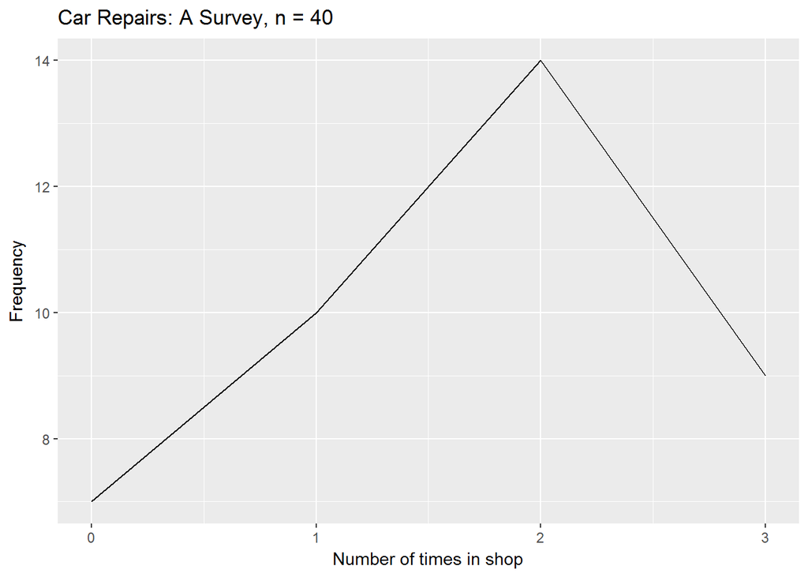

```r
line_plot_1 <- as.data.frame(cbind(times_in_shop, frequencies))

line_plot_1 %>%
  ggplot(aes(x = times_in_shop, y = frequencies)) +
  geom_line() +
  labs( x = "Number of times in shop",
        y = "Frequency",
        title = "Car Repairs: A Survey, n = 40")
```

#### Try It: Bar Graph #1

By the end of 2011, Facebook had over 146 million users in the United States. The table below shows three age groups, the number of users in each age group, and the proportion (%) of users in each age group. Construct a bar graph using this data.

```r
age_groups <- c("13 - 25", "26 - 44", "45 - 64")
number_of_FB_users <- c(65082280, 53300200, 27885100)
proportion_FB_users <- c(45, 36, 19)

kable(as.data.frame(cbind("Age groups" = age_groups,
                          "Number of Facebook users" = number_of_FB_users,
                          "Proportion (%) of Facebook users" = paste(as.character(proportion_FB_users), "%"))))
```

| Age groups | Number of Facebook users | Proportion (%) of Facebook users |
| --- | --- | --- |
| 13 - 25 | 65082280 | 45 % |
| 26 - 44 | 53300200 | 36 % |
| 45 - 64 | 27885100 | 19 % |

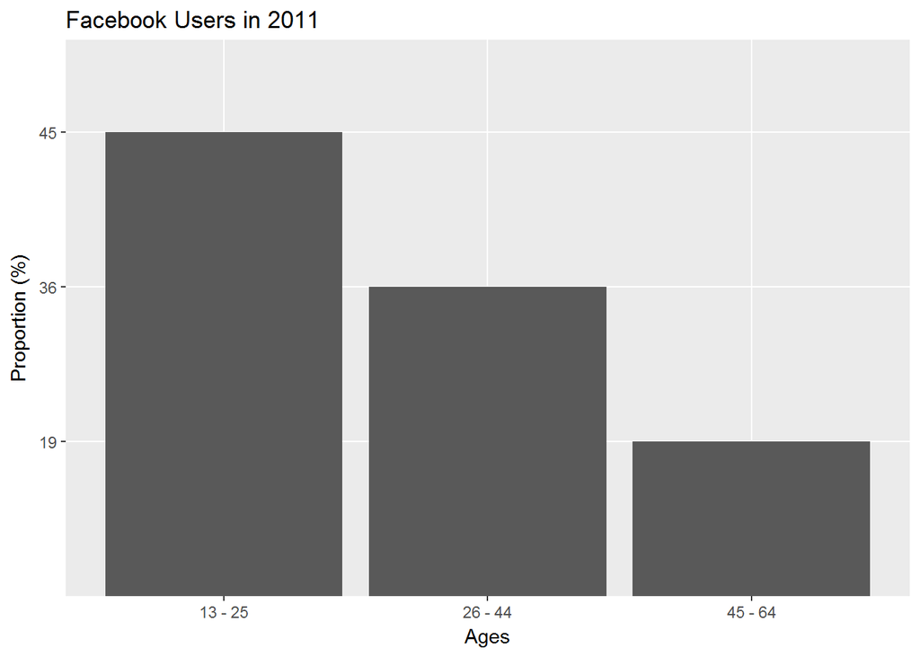

```r
FB_users <- as.data.frame(cbind(age_groups, number_of_FB_users, proportion_FB_users))

FB_users %>%
  ggplot(aes(x = age_groups, y = proportion_FB_users)) +
  geom_bar(stat = "identity") +
  labs( x = "Ages",
        y = "Proportion (%)",
        title = "Facebook Users in 2011")
```

#### Try It: Bar Graph #2

The population in Park City is made up of children, working-age adults, and retirees. The table below shows the three age groups, the number of people in the town from each age group, and the proportion (%) of people in each age group. Construct a bar graph showing the proportions.

```r
age_groups <- c("Children", "Working-age adults", "Retirees")
number_of_people <- c(67059, 152198, 131662)
proportion_of_pop <- c(19, 43, 38)

kable(as.data.frame(cbind("Age groups" = age_groups,
                          "Number of people" = number_of_people,
                          "Proportion of population" = paste(as.character(proportion_of_pop), "%"))))
```

| Age groups | Number of people | Proportion of population |
| --- | --- | --- |
| Children | 67059 | 19 % |
| Working-age adults | 152198 | 43 % |
| Retirees | 131662 | 38 % |

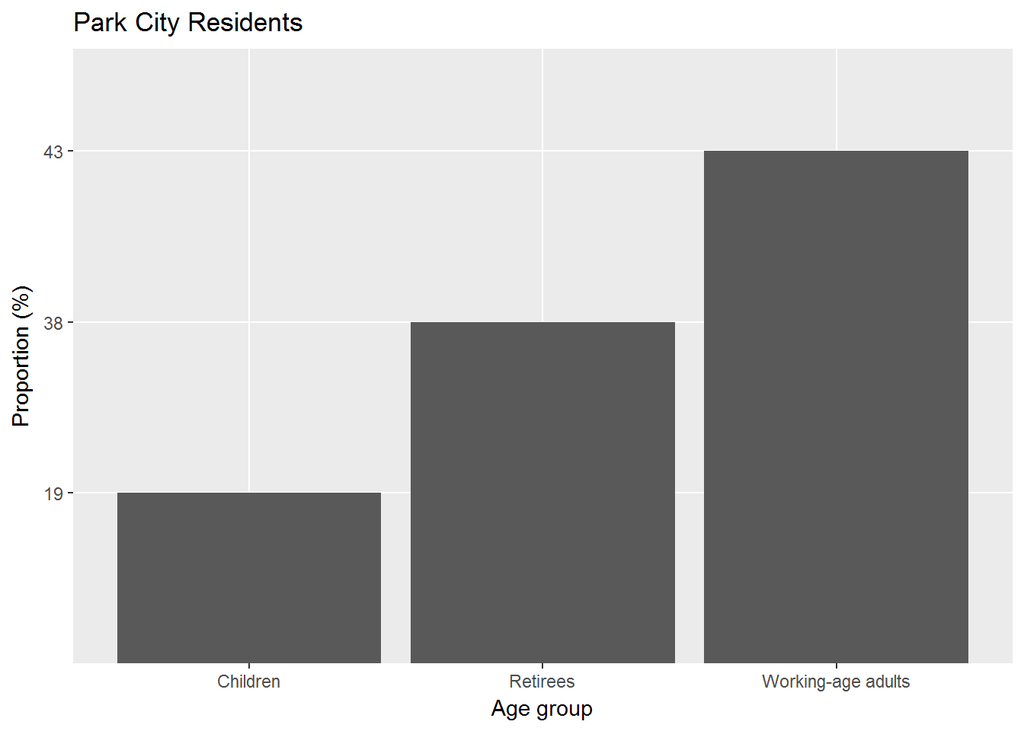

```r
park_city <- as.data.frame(cbind(age_groups, number_of_people, proportion_of_pop))

park_city %>%
  ggplot(aes(x = age_groups, y = proportion_of_pop)) +
  geom_bar(stat = "identity") +
  labs( x = "Age group",
        y = "Proportion (%)",
        title = "Park City Residents")
```

#### Try It: Bar Graph #3

The columns in the table below contain: the race or ethnicity of students in U.S. Public Schools for the class of 2011, percentages for the Advanced Placement examine population for that class, and percentages for the overall student population. Create a bar graph with the student race or ethnicity (qualitative data) on the x-axis, and the Advanced Placement examinee population percentages on the y-axis.

```r
ethnicity <- c("1 = Asian, Asian American or Pacific Islander",
               "2 = Black or African American",
               "3 = Hispanic or Latino",
               "4 = American Indian or Alaska Native",
               "5 = White",
               "6 = Not reported/other")

ap_examinee <- c(10.3, 9.0, 17.0, 0.6, 57.1, 6.0)
overall_pop <- c(5.7, 14.7, 17.6, 1.1, 59.2, 1.7)

kable(as.data.frame(cbind("Race/Ethnicity" = ethnicity,
                          "AP Examinee Population" = paste(as.character(ap_examinee), "%"),
                          "Overall Student Population" = paste(as.character(overall_pop), "%"))))
```

| Race/Ethnicity | AP Examinee Population | Overall Student Population |
| --- | --- | --- |
| 1 = Asian, Asian American or Pacific Islander | 10.3 % | 5.7 % |
| 2 = Black or African American | 9 % | 14.7 % |
| 3 = Hispanic or Latino | 17 % | 17.6 % |
| 4 = American Indian or Alaska Native | 0.6 % | 1.1 % |
| 5 = White | 57.1 % | 59.2 % |
| 6 = Not reported/other | 6 % | 1.7 % |

[figure not shown]

```r
AP_ethnicity <- as.data.frame(cbind(ethnicity, ap_examinee, overall_pop))

AP_ethnicity %>%
  ggplot(aes(x = ethnicity, y = ap_examinee)) +
  geom_bar(stat = "identity") +
  labs( x = "Race / Ethnicity",
        y = "Percent of AP examinees",
        title = "AP Examinees in Public School by Ethnicity") +
  theme(axis.text.x = element_text(angle = 60, hjust = 1))
```

#### Try It: Bar Graph #4

Park city is broken down into six voting districts. The table shows the percent of the total registered voter population that lives in each district as well as the percent total of the entire population that lives in each district. Construct a bar graph that shows the registered voter population by district.

```r
district <- c(1:6)
registered_voters <- c(15.5, 12.2, 9.8, 17.4, 22.8, 22.3)
overall_pop <- c(19.4, 15.6, 9.0, 18.5, 20.7, 16.8)

kable(as.data.frame(cbind("District" = district,
                          "Registered voter population" = paste(as.character(registered_voters), "%"),
                          "Overall city population" = paste(as.character(overall_pop), "%"))))
```

| District | Registered voter population | Overall city population |
| --- | --- | --- |
| 1 | 15.5 % | 19.4 % |
| 2 | 12.2 % | 15.6 % |
| 3 | 9.8 % | 9 % |
| 4 | 17.4 % | 18.5 % |
| 5 | 22.8 % | 20.7 % |
| 6 | 22.3 % | 16.8 % |

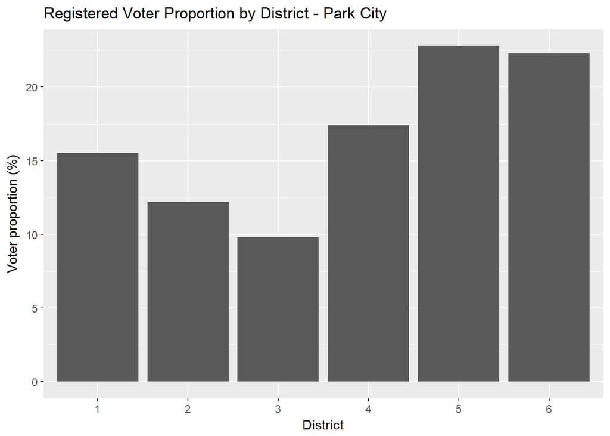

```r
park_city_votes <- as.data.frame(cbind(district, registered_voters, overall_pop))

park_city_votes %>%
  ggplot(aes(x = as.character(district), y = registered_voters)) +
  geom_bar(stat = "identity") +
  labs( x = "District",
        y = "Voter proportion (%)",
        title = "Registered Voter Proportion by District - Park City")
```